# Introduction to R: Homework 2 - Key

**Hint:** use `length()` with `unique()` or `table()`. Remember to `pull()` the right column.

```r
mars %>%
  pull(UV_Radiation) %>%
  unique() %>%
  length()
```

```
## [1] 4
```

```r
# OR
length(unique(mars %>% pull(UV_Radiation)))
```

```
## [1] 4
```

```r
# OR
length(unique(mars$UV_Radiation))
```

```
## [1] 4
```

```r
# OR
table(unique(mars$UV_Radiation))
```

```
##
##      high       low  moderate very_high
##         1         1         1         1
```

```r
# 4 unique levels.
```

15. How many different weather conditions (“weather”) are reported?

```r
mars %>%
  pull(weather) %>%
  unique() %>%
  length()
```

```
## [1] 1
```

```r
# 1 weather condition.
```

16. Which UV radiation level had the highest maximum air temperature, and what was it?

**Hint:** Use `group_by()` with `summarize()`.

```r
mars %>%
  group_by(UV_Radiation) %>%
  summarize(mean = mean(max_air_temp))
```

```
## # A tibble: 4 × 2
##   UV_Radiation   mean
##   <chr>         <dbl>
## 1 high           5.66
## 2 low          -11.3
## 3 moderate      -1.38
## 4 very_high     12.5
```

17. Extend on the code you wrote for question 16. Use the `arrange()` function to sort the output by maximum air temperature.

```r
mars %>%
  group_by(UV_Radiation) %>%
  summarize(mean = mean(max_air_temp)) %>%
  arrange(desc(mean))
```

```
## # A tibble: 4 × 2
##   UV_Radiation   mean
##   <chr>         <dbl>
## 1 very_high     12.5
## 2 high           5.66
## 3 moderate      -1.38
## 4 low          -11.3
```

18. How many measurements were taken on days when the UV radiation was “low” and the maximum air temperature was above freezing? Use:

- `filter()` and `count()`
- `filter()` and `tally()` or
- `sum()`

```r
mars %>%
  filter(UV_Radiation == "low" & max_air_temp > 0) %>%
  tally()
```

```
## # A tibble: 1 × 1
##       n
##   <int>
## 1     3
```

```r
# OR
mars %>%
  filter(UV_Radiation == "low" & max_air_temp > 0) %>%
  count()
```

```
## # A tibble: 1 × 1
##       n
##   <int>
## 1     3
```

```r
# OR
sum(mars$UV_Radiation == "low" & mars$max_air_temp > 0)
```

```
## [1] 3
```

```r
# A total of 3 days.
```

19. How many days was the UV radiation was “high” or “very high”? use:

- `filter()` and `count()`
- `filter()` and `tally()` or
- `sum()`

```r
mars %>%
  filter(UV_Radiation == "high" | UV_Radiation == "very_high") %>%
  count()
```

```
## # A tibble: 1 × 1
##       n
##   <int>
## 1  1125
```

```r
# OR
mars %>%
  filter(UV_Radiation %in% c("high", "very_high")) %>%
  count()
```

```
## # A tibble: 1 × 1
##       n
##   <int>
## 1  1125
```

```r
# OR
sum(mars$UV_Radiation == "high" | mars$UV_Radiation == "very_high")
```

```
## [1] 1125
```

```r
# OR
sum(mars$UV_Radiation %in% c("high", "very_high"))
```

```
## [1] 1125
```

```r
# A total of 1125 days.
```

20. Select all columns in “mars” where the column names starts with “min” (using `select()` and `starts_with()`. Then, use `colMeans()` to summarize across these columns.

```r
mars %>%
  select(starts_with("min")) %>%
  colMeans()
```

```
## min_ground_temp    min_air_temp
##       -74.94317       -80.56080
```

21. Using “mars”, create a new binary (TRUEs and FALSEs) column to indicate if the day’s maximum air temperature was above freezing. Call the new column “above_freezing”.

```r
mars <- mars %>% mutate(above_freezing = (max_air_temp > 0))
```

22. What is the average atmospheric pressure for days that have an air temperature above freezing and UV radiation level of “moderate”? How does this compare with days that do NOT fit these criteria?

```r
mean_mod_warm <- mars %>%
  filter(above_freezing == TRUE & UV_Radiation == "moderate") %>%
  summarize(mean = mean(mean_pressure)) %>%
  pull()

mean_not_mod_warm <- mars %>%
  filter(above_freezing != TRUE | UV_Radiation != "moderate") %>%
  summarize(mean = mean(mean_pressure)) %>%
  pull()

# Days that are above freezing with UV level of "moderate" have an average atmospheric pressure of 820.7 Pa while days not fitting this criteria have an average atmospheric pressure of 826.6 Pa.
```

23. Among days with a “moderate” UV level that are above freezing, what is the distribution of the earth year in which these days occurred?

```r
mod_warm <- mars %>% filter(UV_Radiation == "moderate" & above_freezing == TRUE)
mod_warm %>%
  group_by(earth_year) %>%
  select(earth_year) %>%
  table()
```

```
## earth_year
## 2015 2016 2017 2018 2019 2020 2021 2022
##   41   31    6   74   72  152  126   17
```

```r
# OR
mod_warm <- mars %>% filter(UV_Radiation == "moderate" & above_freezing == TRUE)
mod_warm %>%
  group_by(earth_year) %>%
  count()
```

```
## # A tibble: 8 × 2
## # Groups:   earth_year [8]
##   earth_year     n
##        <dbl> <int>
## 1       2015    41
## 2       2016    31
## 3       2017     6
## 4       2018    74
## 5       2019    72
## 6       2020   152
## 7       2021   126
## 8       2022    17
```

```r
# OR
mod_warm <- mars %>% filter(UV_Radiation == "moderate" & above_freezing == TRUE)
mod_warm %>%
  group_by(earth_year) %>%
  tally()
```

```
## # A tibble: 8 × 2
##   earth_year     n
##        <dbl> <int>
## 1       2015    41
## 2       2016    31
## 3       2017     6
## 4       2018    74
## 5       2019    72
## 6       2020   152
## 7       2021   126
## 8       2022    17
```

24. How many days (using `filter()` or `sum()` ) have a maximum ground or air temperature above zero and have a UV level of “high” or “very_high”?

```r
sum((mars$max_ground_temp > 0| mars$max_air_temp > 0) & (mars$UV_Radiation == "high" | mars$UV_Radiation == "very_high"))
```

```
## [1] 886
```

```r
# OR
sum((mars$max_ground_temp > 0| mars$max_air_temp > 0) & mars$UV_Radiation %in% c("high", "very_high"))
```

```
## [1] 886
```

```r
# OR
mars %>%
  filter((mars$max_ground_temp > 0| mars$max_air_temp > 0) & mars$UV_Radiation %in% c("high", "very_high")) %>%
  count()
```

```
## # A tibble: 1 × 1
##       n
##   <int>
## 1   886
```

```r
# A total of 886 days.
```

25. Make a boxplot (`boxplot()`) that looks at earth year (“earth_year”) on the x-axis and minimum air temperature (“min_air_temp”) on the y-axis.

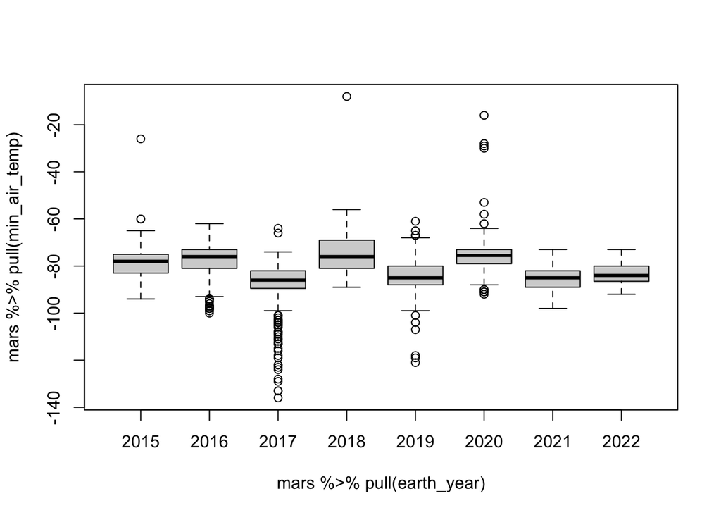

```r
boxplot(mars %>% pull(min_air_temp) ~ mars %>% pull(earth_year))
```

26. Knit your document into a report.

You use the knit button to do this. Make sure all your code is working first!